# Lab 4 Assignment

Dhananjay

2023-03-20

## Q1. Compare Bar and Pie Plots

Consider the dataset below. Please construct two plots to visualize this data: a sorted bar plot and a pie chart. Make sure both plots have easy to read labels and grid lines for reference. http://eecs.ucf.edu/~wiegand/idc6700/datasets/doctorwho.csv

```r
# Loading the required libraries
library(tidyverse)
```

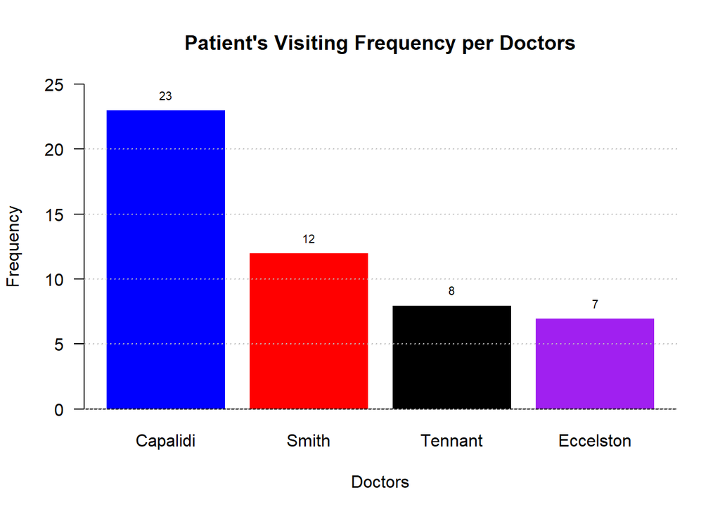

```r
library(ggplot2)

# Loading the doctorwho dataset
doctorWhodf <- read.csv("doctorwho.csv", header = TRUE, sep = ",")

# Computing the frequency of each doctor
doctorFrequency <- table(doctorWhodf$FavoriteDoctor)

# Sorting the frequency in descending order
sortedDoctorFrequency <- sort(doctorFrequency, decreasing = TRUE)

# Creating a vector of colors for each doctor
doctorColors <- c("blue", "red", "black", "purple")

# creating a sorted bar plot with different colors and grid lines
doctor_bp <- barplot(sortedDoctorFrequency,
              main = "Patient's Visiting Frequency per Doctors",
              xlab = "Doctors",
              ylab = "Frequency",
              col = doctorColors,
              border = "white",
              ylim = c(0, 25),
              las = 1,
              cex.names = 1,
              horiz = FALSE,
              yaxs = "i")

# Adding a horizontal grid line at the x-axis
abline(h = 0, v = NULL, col = "black", lty = "solid")

# Adding horizontal grid lines at each y-interval
abline(h = seq(0, 20, by = 5), v = NULL, lty = "dotted", col = "gray")

# Adding frequency values on top of each bar
text(doctor_bp, sortedDoctorFrequency, labels = sortedDoctorFrequency, pos = 3, cex = 0.7)
```

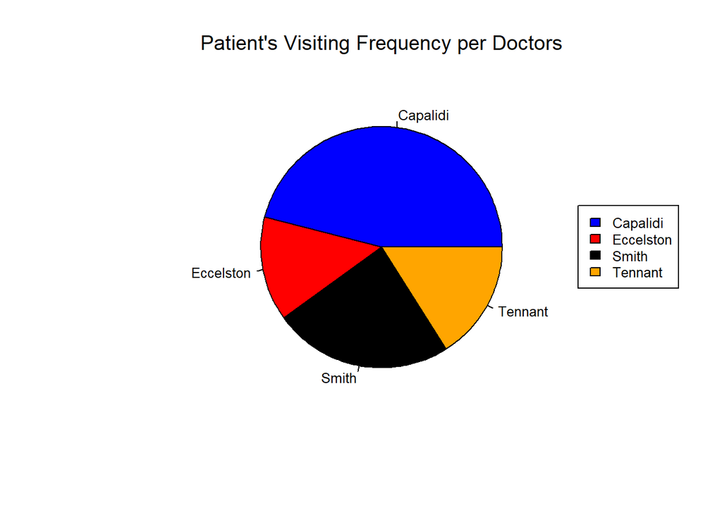

```r
# Loading the required libraries
library(tidyverse)
library(ggplot2)

# Loading the doctorwho dataset
doctorWhodf <- read.csv("doctorwho.csv", header = TRUE, sep = ",")

# Computing the frequency of each doctor
doctorFrequency <- table(doctorWhodf$FavoriteDoctor)

# Sorting the frequency in descending order
# sortedDoctorFrequency <- sort(doctorFrequency, decreasing = TRUE)

# Creating a vector of colors for each doctor
doctorColors <- c("blue", "red", "black", "orange")

# Creating the pie chart for the data
pie(doctorFrequency,
    labels = names(doctorFrequency),
    col = doctorColors,
    main = "Patient's Visiting Frequency per Doctors",
    cex = 0.8,
    font.main = 1,
    font.lab = 1,
    font.axis = 1)

# Adding the grid lines
# grid(lty = 3, lwd = 0.5, col = "gray")

# Adding the legend to the pie chart
legend("right", cex = 0.8, legend = names(doctorFrequency), fill = doctorColors)
```

## Q2. A Simple Time Series

The standard R base comes with a multivariate time series data set for major European stock indices from 1991 to 1998 in “ts” format (EuStockMarkets). Display a paneled plot of the four indices represented (hint: Don’t use ggplot2–consider R’s built-in plotting functions).

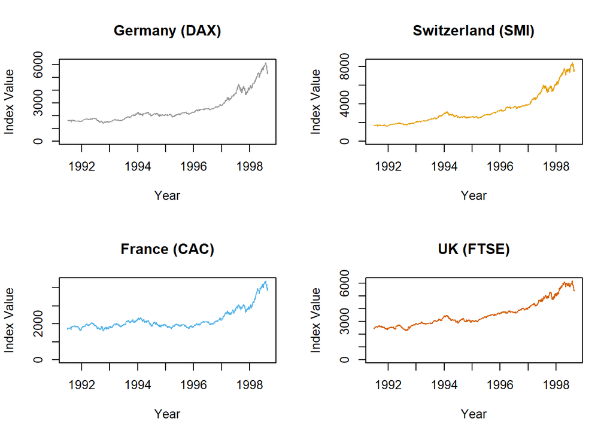

```r
# Loading the EuStockMarkets dataset
data(EuStockMarkets)

# Creating a 2x2 plot panel for the four indices
par(mfrow = c(2, 2))

# Creating a plot for each of the four indices with different colors and axis limits
plot(EuStockMarkets[, "DAX"], type = "l", main = "Germany (DAX)", col = "#999999", ylab = "Index Value", xlab = "Year", ylim = c(0, ceiling(max(EuStockMarkets[, "DAX"]))))
plot(EuStockMarkets[, "SMI"], type = "l", main = "Switzerland (SMI)", col = "#E69F00", ylab = "Index Value", xlab = "Year", ylim = c(0, ceiling(max(EuStockMarkets[, "SMI"]))))
plot(EuStockMarkets[, "CAC"], type = "l", main = "France (CAC)", col = "#56B4E9", ylab = "Index Value", xlab = "Year", ylim = c(0, ceiling(max(EuStockMarkets[, "CAC"]))))
plot(EuStockMarkets[, "FTSE"], type = "l", main = "UK (FTSE)", col = "#D55E00", ylab = "Index Value", xlab = "Year", ylim = c(0, ceiling(max(EuStockMarkets[, "FTSE"]))))
```

## Q3. Third item

A certain measurement tool collects statistics about server performance once a day and reports the instantaneous measure at that moment. The following data set represents the measured number of requests per second for each day in 2014: (http://cs.ucf.edu/~wiegand/ids6938/datasets/RequestData.csv) Plot a scatter-plot of the continuous time series data. Fit a smoothed curve to the data over the year, as well. Hint: You can convert the data string to a date type (which will help with plotting the x-axis) as follows:

```r
... aes(x=strptime(Day,"%m-%d-%Y") ...
```

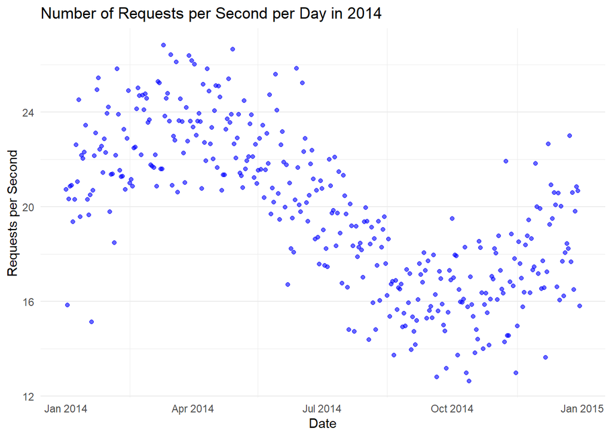

```r
# Loading the required libraries
library(tidyverse)
library(ggplot2)

# Loading the RequestData dataset
requestDatadf <- read.csv("RequestData.csv", header = TRUE, sep = ",")
# head(requestDatadf)

# Converting the "Day" column to POSIXct object
requestDatadf$Day <- as.POSIXct(requestDatadf$Day, format="%m-%d-%Y")

# Creating the scatter-plot of the continuous time-series data
ggplot(requestDatadf, aes(x=Day, y=RequestsPerSecond)) +
  geom_point(size = 1.5, alpha = 0.6, color = "blue") +
  labs(title = "Number of Requests per Second per Day in 2014",
       x = "Date",
       y = "Requests per Second") +
  theme_minimal() +
  theme(panel.grid.major.x = element_blank())
```

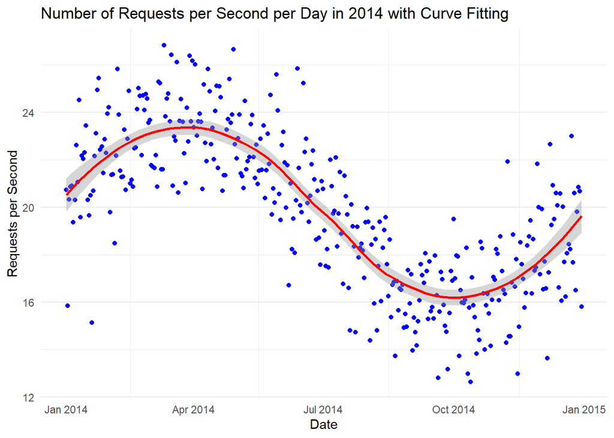

```r
# Creating the scatter-plot of the continuous time-series data and fitting a smoothed curve
ggplot(requestDatadf, aes(x=Day, y=RequestsPerSecond)) +
  geom_point(color = "blue") +
  geom_smooth(method = "loess", se = TRUE, color = "red") +
  labs(title = "Number of Requests per Second per Day in 2014 with Curve Fitting",
       x = "Date",
       y = "Requests per Second") +
  theme_minimal() +
  theme(panel.grid.major.x = element_blank())
```

## Q4. UCF Building Energy Usage Time Series

Data for 5 UCF building structures are in the data folder of this repository.

- Read in the datasets into R, and list what data is being captured for each building.

```r
# Loading the libraries
library(tidyverse)

# Loading the 5 UCF Building Structures datasets

# Reading the UCF Biological Sciences building dataset
biologicalSciencesdf <- read.csv("2021-UCF Biological Sciences.csv", header = TRUE, sep = ";")

# Listing the data that is being captured for the Biological Sciences building
str(biologicalSciencesdf)
```

```
## 'data.frame':    8736 obs. of  1 variable:
##  $ Timestamp.Electric.Water.Chilled.Water.Gas: chr  "2021-01-01 00:00:00\t1,275.71\t30.00\t\t1,333.06" "2021-01-01 01:00:00\t1,281.85\t35.00\t\t1,428.28" "2021-01-01 02:00:00\t1,277.75\t141.00\t\t1,278.65" "2021-01-01 03:00:00\t1,271.61\t150.00\t\t1,265.05" ...
```

```r
head(biologicalSciencesdf)
```

```
##          Timestamp.Electric.Water.Chilled.Water.Gas
## 1  2021-01-01 00:00:00\t1,275.71\t30.00\t\t1,333.06
## 2  2021-01-01 01:00:00\t1,281.85\t35.00\t\t1,428.28
## 3 2021-01-01 02:00:00\t1,277.75\t141.00\t\t1,278.65
## 4 2021-01-01 03:00:00\t1,271.61\t150.00\t\t1,265.05
## 5  2021-01-01 04:00:00\t1,276.39\t24.00\t\t1,333.06
## 6  2021-01-01 05:00:00\t1,282.53\t25.00\t\t1,414.68
```

```r
#print(biologicalSciencesdf)
summary(biologicalSciencesdf)
```

```
##  Timestamp.Electric.Water.Chilled.Water.Gas
##  Length:8736
##  Class :character
##  Mode  :character
```

```r
# Reading the UCF CFE Federal Credit Union Arena building dataset
cfeCreditUnionArenadf <- read.csv("2021-UCF CFE Federal Credit Union Arena.csv", header = TRUE, sep = ";")

# Listing the data that is being captured for the CFE Federal Credit Union Arena building
str(cfeCreditUnionArenadf)
```

```
## 'data.frame':    8736 obs. of  1 variable:
##  $ Timestamp.Electric.Water: chr  "2021-01-01 00:00:00\t996.54\t100.00" "2021-01-01 01:00:00\t944.32\t120.00" "2021-01-01 02:00:00\t899.61\t100.00" "2021-01-01 03:00:00\t874.70\t110.00" ...
```

```r
head(cfeCreditUnionArenadf)
```

```
##              Timestamp.Electric.Water
## 1 2021-01-01 00:00:00\t996.54\t100.00
## 2 2021-01-01 01:00:00\t944.32\t120.00
## 3 2021-01-01 02:00:00\t899.61\t100.00
## 4 2021-01-01 03:00:00\t874.70\t110.00
## 5  2021-01-01 04:00:00\t938.18\t50.00
## 6  2021-01-01 05:00:00\t946.03\t60.00
```

```r
#print(cfeCreditUnionArenadf)
summary(cfeCreditUnionArenadf)
```

```
##  Timestamp.Electric.Water
##  Length:8736
##  Class :character
##  Mode  :character
```

```r
# Reading the UCF Milican Hall building dataset
milicanHalldf <- read.csv("2021-UCF Milican Hall.csv", header = TRUE, sep = ";")

# Listing the data that is being captured for the Milican Hall building
str(milicanHalldf)
```

```
## 'data.frame':    8736 obs. of  1 variable:
##  $ Timestamp.Electric: chr  "2021-01-01 00:00:00\t232.75" "2021-01-01 01:00:00\t260.06" "2021-01-01 02:00:00\t260.06" "2021-01-01 03:00:00\t255.96" ...
```

```r
head(milicanHalldf)
```

```
##            Timestamp.Electric
## 1 2021-01-01 00:00:00\t232.75
## 2 2021-01-01 01:00:00\t260.06
## 3 2021-01-01 02:00:00\t260.06
## 4 2021-01-01 03:00:00\t255.96
## 5 2021-01-01 04:00:00\t262.10
## 6 2021-01-01 05:00:00\t288.72
```

```r
#print(milicanHalldf)
summary(milicanHalldf)
```

```
##  Timestamp.Electric
##  Length:8736
##  Class :character
##  Mode  :character
```

```r
# Reading the UCF Student Union building dataset
studentUniondf <- read.csv("2021-UCF Student Union.csv", header = TRUE, sep = ";")

# Listing the data that is being captured for the Student Union building
str(studentUniondf)
```

```
## 'data.frame':    8736 obs. of  1 variable:
##  $ Timestamp.Electric.Water.Gas: chr  "2021-01-01 00:00:00\t1,182.52\t0.00\t0.00" "2021-01-01 01:00:00\t1,239.99\t0.00\t20.50" "2021-01-01 02:00:00\t1,238.84\t0.00\t0.00" "2021-01-01 03:00:00\t1,246.69\t0.00\t0.00" ...
```

```r
head(studentUniondf)
```

```
##                 Timestamp.Electric.Water.Gas
## 1  2021-01-01 00:00:00\t1,182.52\t0.00\t0.00
## 2 2021-01-01 01:00:00\t1,239.99\t0.00\t20.50
## 3  2021-01-01 02:00:00\t1,238.84\t0.00\t0.00
## 4  2021-01-01 03:00:00\t1,246.69\t0.00\t0.00
## 5 2021-01-01 04:00:00\t1,220.40\t0.00\t20.50
## 6  2021-01-01 05:00:00\t1,218.36\t0.00\t0.00
```

```r
#print(studentUniondf)
summary(studentUniondf)
```

```
##  Timestamp.Electric.Water.Gas
##  Length:8736
##  Class :character
##  Mode  :character
```

```r
# Reading the UCF Trevor Colbourn Hall building dataset
trevorColbournHalldf <- read.csv("2021-UCF Trevor Colbourn Hall.csv", header = TRUE, sep = ";")

# Listing the data that is being captured for the Trevor Colbourn Hall building
str(trevorColbournHalldf)
```

```
## 'data.frame':    8736 obs. of  1 variable:
##  $ Timestamp.Electric.Water.Chilled.Water.Irrigation: chr  "2021-01-01 00:00:00\t206.13\t0.00\t48.01\t0.00" "2021-01-01 01:00:00\t183.95\t0.00\t36.01\t0.00" "2021-01-01 02:00:00\t189.41\t0.30\t48.01\t0.00" "2021-01-01 03:00:00\t191.12\t2.80\t48.01\t0.00" ...
```

```r
head(trevorColbournHalldf)
```

```
##   Timestamp.Electric.Water.Chilled.Water.Irrigation
## 1    2021-01-01 00:00:00\t206.13\t0.00\t48.01\t0.00
## 2    2021-01-01 01:00:00\t183.95\t0.00\t36.01\t0.00
## 3    2021-01-01 02:00:00\t189.41\t0.30\t48.01\t0.00
## 4    2021-01-01 03:00:00\t191.12\t2.80\t48.01\t0.00
## 5    2021-01-01 04:00:00\t189.41\t0.00\t60.01\t0.00
## 6    2021-01-01 05:00:00\t178.83\t0.00\t48.01\t0.00
```

```r
#print(trevorColbournHalldf)
summary(trevorColbournHalldf)
```

```
##  Timestamp.Electric.Water.Chilled.Water.Irrigation
##  Length:8736
##  Class :character
##  Mode  :character
```

```r
# Loading the libraries
library(tidyverse)
library(ggplot2)
library(dplyr)
library(zoo)
library(lubridate)
# Loading the 5 UCF Building Structures datasets

# Reading the UCF Biological Sciences building dataset
biologicalSciencesdf <- read.csv("2021-UCF Biological Sciences.csv", header = TRUE, sep = ";")


# Reading the UCF CFE Federal Credit Union Arena building dataset
cfeCreditUnionArenadf <- read.csv("2021-UCF CFE Federal Credit Union Arena.csv", header = TRUE, sep = ";")

# Reading the UCF Milican Hall building dataset
milicanHalldf <- read.csv("2021-UCF Milican Hall.csv", header = TRUE, sep = ";")

# Reading the UCF Student Union building dataset
studentUniondf <- read.csv("2021-UCF Student Union.csv", header = TRUE, sep = ";")

# Reading the UCF Trevor Colbourn Hall building dataset
trevorColbournHalldf <- read.csv("2021-UCF Trevor Colbourn Hall.csv", header = TRUE, sep = ";")
```

```r
# Loading the libraries
library(tidyverse)
library(ggplot2)
library(dplyr)
library(zoo)
library(lubridate)

# Loading the 5 UCF Building Structures datasets

# Reading the UCF Biological Sciences building dataset
biologicalSciencesdf <- read.csv("2021-UCF Biological Sciences.csv", header = TRUE, sep = ";")

# Reading the UCF CFE Federal Credit Union Arena building dataset
cfeCreditUnionArenadf <- read.csv("2021-UCF CFE Federal Credit Union Arena.csv", header = TRUE, sep = ";")

# Reading the UCF Milican Hall building dataset
milicanHalldf <- read.csv("2021-UCF Milican Hall.csv", header = TRUE, sep = ";")

# Reading the UCF Student Union building dataset
studentUniondf <- read.csv("2021-UCF Student Union.csv", header = TRUE, sep = ";")

# Reading the UCF Trevor Colbourn Hall building dataset
trevorColbournHalldf <- read.csv("2021-UCF Trevor Colbourn Hall.csv", header = TRUE, sep = ";")
```

```r
# Loading the libraries
library(tidyverse)
library(ggplot2)
library(dplyr)
library(zoo)
library(lubridate)

# Loading the 5 UCF Building Structures datasets

# Reading the UCF Biological Sciences building dataset
biologicalSciencesdf <- read.csv("2021-UCF Biological Sciences.csv", header = TRUE, sep = ";")

head(biologicalSciencesdf)
```

```
##          Timestamp.Electric.Water.Chilled.Water.Gas
## 1  2021-01-01 00:00:00\t1,275.71\t30.00\t\t1,333.06
## 2  2021-01-01 01:00:00\t1,281.85\t35.00\t\t1,428.28
## 3 2021-01-01 02:00:00\t1,277.75\t141.00\t\t1,278.65
## 4 2021-01-01 03:00:00\t1,271.61\t150.00\t\t1,265.05
## 5  2021-01-01 04:00:00\t1,276.39\t24.00\t\t1,333.06
## 6  2021-01-01 05:00:00\t1,282.53\t25.00\t\t1,414.68
```

```r
# biologicalSciencesdf$Electric <- as.numeric(biologicalSciencesdf$Electric, na.rm = TRUE)

# Performing decomposition of each data field for Biological Sciences building using stl
# biologicalSciencesdfDecomposed <- stl(biologicalSciencesdf$Electric, s.window = "periodic")
```

```r
# Loading the libraries
library(tidyverse)
library(ggplot2)
library(dplyr)
library(zoo)
library(lubridate)
library(fmsb)
# Loading the 5 UCF Building Structures datasets

# Reading the UCF Biological Sciences building dataset
biologicalSciencesdf <- read.csv("2021-UCF Biological Sciences.csv", header = TRUE, sep = ";")

# Reading the UCF CFE Federal Credit Union Arena building dataset
cfeCreditUnionArenadf <- read.csv("2021-UCF CFE Federal Credit Union Arena.csv", header = TRUE, sep = ";")

# Reading the UCF Milican Hall building dataset
milicanHalldf <- read.csv("2021-UCF Milican Hall.csv", header = TRUE, sep = ";")

# Reading the UCF Student Union building dataset
studentUniondf <- read.csv("2021-UCF Student Union.csv", header = TRUE, sep = ";")

# Reading the UCF Trevor Colbourn Hall building dataset
trevorColbournHalldf <- read.csv("2021-UCF Trevor Colbourn Hall.csv", header = TRUE, sep = ";")


# Creating a data frame with the electricity data for each building
datadf <- data.frame(
  Biological_Sciences = as.numeric(biologicalSciencesdf$Electric),
  CFE_Credit_Union_Arena = as.numeric(cfeCreditUnionArenadf$Electric),
  Milican_Hall = as.numeric(milicanHalldf$Electric),
  Student_Union = as.numeric(studentUniondf$Electric),
  Trevor_Colbourn_Hall = as.numeric(trevorColbournHalldf$Electric)
)


# data <- as.data.frame(datadf)
# dim(data)

# Creating a vector of labels for the radar plot
labels <- c("Biological Sciences", "CFE Credit Union Arena", "Milican Hall", "Student Union", "Trevor Colbourn Hall")
```

```r
# Load the ggplot2 package
library(ggplot2)

# Loading the 5 UCF Building Structures datasets

# Reading the UCF Biological Sciences building dataset
biologicalSciencesdf <- read.csv("2021-UCF Biological Sciences.csv", header = TRUE, sep = ";")

# Reading the UCF CFE Federal Credit Union Arena building dataset
cfeCreditUnionArenadf <- read.csv("2021-UCF CFE Federal Credit Union Arena.csv", header = TRUE, sep = ";")

# Reading the UCF Milican Hall building dataset
milicanHalldf <- read.csv("2021-UCF Milican Hall.csv", header = TRUE, sep = ";")

# Reading the UCF Student Union building dataset
studentUniondf <- read.csv("2021-UCF Student Union.csv", header = TRUE, sep = ";")

# Reading the UCF Trevor Colbourn Hall building dataset
trevorColbournHalldf <- read.csv("2021-UCF Trevor Colbourn Hall.csv", header = TRUE, sep = ";")

# Check the column names of each data frame
names(biologicalSciencesdf)
```

```
## [1] "Timestamp.Electric.Water.Chilled.Water.Gas"
```

```r
names(cfeCreditUnionArenadf)
```

```
## [1] "Timestamp.Electric.Water"
```

```r
names(milicanHalldf)
```

```
## [1] "Timestamp.Electric"
```

```r
names(studentUniondf)
```

```
## [1] "Timestamp.Electric.Water.Gas"
```

```r
names(trevorColbournHalldf)
```

```
## [1] "Timestamp.Electric.Water.Chilled.Water.Irrigation"
```

```r
# Check the structure of each data frame
str(biologicalSciencesdf)
```

```
## 'data.frame':    8736 obs. of  1 variable:
##  $ Timestamp.Electric.Water.Chilled.Water.Gas: chr  "2021-01-01 00:00:00\t1,275.71\t30.00\t\t1,333.06" "2021-01-01 01:00:00\t1,281.85\t35.00\t\t1,428.28" "2021-01-01 02:00:00\t1,277.75\t141.00\t\t1,278.65" "2021-01-01 03:00:00\t1,271.61\t150.00\t\t1,265.05" ...
```

```r
str(cfeCreditUnionArenadf)
```

```
## 'data.frame':    8736 obs. of  1 variable:
##  $ Timestamp.Electric.Water: chr  "2021-01-01 00:00:00\t996.54\t100.00" "2021-01-01 01:00:00\t944.32\t120.00" "2021-01-01 02:00:00\t899.61\t100.00" "2021-01-01 03:00:00\t874.70\t110.00" ...
```

```r
str(milicanHalldf)
```

```
## 'data.frame':    8736 obs. of  1 variable:
##  $ Timestamp.Electric: chr  "2021-01-01 00:00:00\t232.75" "2021-01-01 01:00:00\t260.06" "2021-01-01 02:00:00\t260.06" "2021-01-01 03:00:00\t255.96" ...
```

```r
str(studentUniondf)
```

```
## 'data.frame':    8736 obs. of  1 variable:
##  $ Timestamp.Electric.Water.Gas: chr  "2021-01-01 00:00:00\t1,182.52\t0.00\t0.00" "2021-01-01 01:00:00\t1,239.99\t0.00\t20.50" "2021-01-01 02:00:00\t1,238.84\t0.00\t0.00" "2021-01-01 03:00:00\t1,246.69\t0.00\t0.00" ...
```

```r
str(trevorColbournHalldf)
```

```
## 'data.frame':    8736 obs. of  1 variable:
##  $ Timestamp.Electric.Water.Chilled.Water.Irrigation: chr  "2021-01-01 00:00:00\t206.13\t0.00\t48.01\t0.00" "2021-01-01 01:00:00\t183.95\t0.00\t36.01\t0.00" "2021-01-01 02:00:00\t189.41\t0.30\t48.01\t0.00" "2021-01-01 03:00:00\t191.12\t2.80\t48.01\t0.00" ...
```